# PASI2

Gerardo Fumagal

2/15/2021

## Analysis of ToothGrowth data set

The ToothGrowth data set in r, is a collection of observations on guinea pigs tooth growth due to the application of Vitamin C dosis. In this paper, we will analyze the content of this data set, by getting information on the number of observations, the variables captured and by doing basis statistical analysis of the data with preliminary conclusions.

```r
data = ToothGrowth
```

###Exploratory Data Analisys

To get an understanding of the ToothGrowth set, we will explore the data as per the following steps:

1. Number of observations captured.
2. Number, name and type of variables within the data set.
3. Existing levels of variables, and unique values for each.

Let’s explore the data set:

```r
dim(data)
```

```
## [1] 60  3
```

```r
str(data)
```

```
## 'data.frame':    60 obs. of  3 variables:
##  $ len : num  4.2 11.5 7.3 5.8 6.4 10 11.2 11.2 5.2 7 ...
##  $ supp: Factor w/ 2 levels "OJ","VC": 2 2 2 2 2 2 2 2 2 2 ...
##  $ dose: num  0.5 0.5 0.5 0.5 0.5 0.5 0.5 0.5 0.5 0.5 ...
```

ToothGrowth data set is a collection of 60 observations containing the variables tooth length, supplementary type and dose. Length is a numeric variable, supplementary type is a factor variable with 2 levels and dose is another numeric variable.

Now we get more information by making a summary on the database and extracting the unique values from dose variable:

```r
summary(data)
```

```
##       len        supp         dose
##  Min.   : 4.20   OJ:30   Min.   :0.500
##  1st Qu.:13.07   VC:30   1st Qu.:0.500
##  Median :19.25           Median :1.000
##  Mean   :18.81           Mean   :1.167
##  3rd Qu.:25.27           3rd Qu.:2.000
##  Max.   :33.90           Max.   :2.000
```

```r
unique(data$dose)
```

```
## [1] 0.5 1.0 2.0
```

We noticed there were 2 groups for testing each of 30 pigs identified by the supplementary type variable as VC and OC, they received either one of 3 different doses level: 0.5, 1.0 or 2.0 units.

## Statistical Analysis

The main goal in this section is to find out relationships between the length of tooth with dose and supplementary type.

Let’s start with supplementary type, a variable with 2 levels: VC or OJ. We need to, find out the distribution for each level

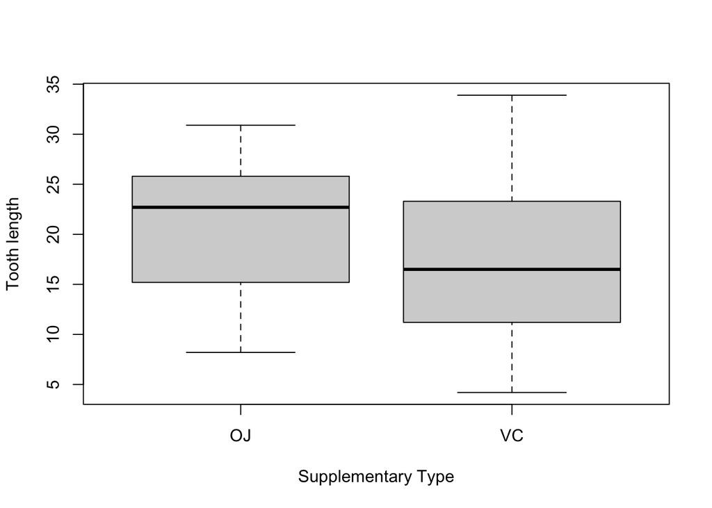

```r
plot(x = data$supp, y = data$len, xlab = "Supplementary Type", ylab = "Tooth length")
```

By looking at the graph, there is a perception of OJ median is higher than the one for VC, so let this be our first hypothesis.

The null hypothesis is the difference between the expected value of the tooth length with supplementary type OJ is equal to the expected value with type VC, the alternative is, the expected value with supplementary type OJ is higher than with type VC:

$$\begin{equation}
H_{0} \textrm{ | } \mu_{OJ} = \mu_{VC} \\
H_{a} \textrm{ | } \mu_{OJ} > \mu_{VC}
\end{equation}$$

```r
x_oj <- with(data, len[supp == "OJ"])
x_vc <- with(data, len[supp == "VC"])
t.test(x_oj - x_vc, paired = FALSE, var.equal = TRUE)
```

```
##
##  One Sample t-test
##
## data:  x_oj - x_vc
## t = 3.3026, df = 29, p-value = 0.00255
## alternative hypothesis: true mean is not equal to 0
## 95 percent confidence interval:
##  1.408659 5.991341
## sample estimates:
## mean of x
##       3.7
```

Based on the output from the t-test, we reject the null hypothesis as our 95% confidence interval (1.408659 5.991341), does not include 0, and as the interval is clearly on the positive side, we can conclude the supplementary type OJ has a positive effect on tooth length.

## Analysis of dose and supplementary type effects on tooth length

Let’s visualize the data by dose and supplementary type at the same time, in order to recognize some preliminary patterns.

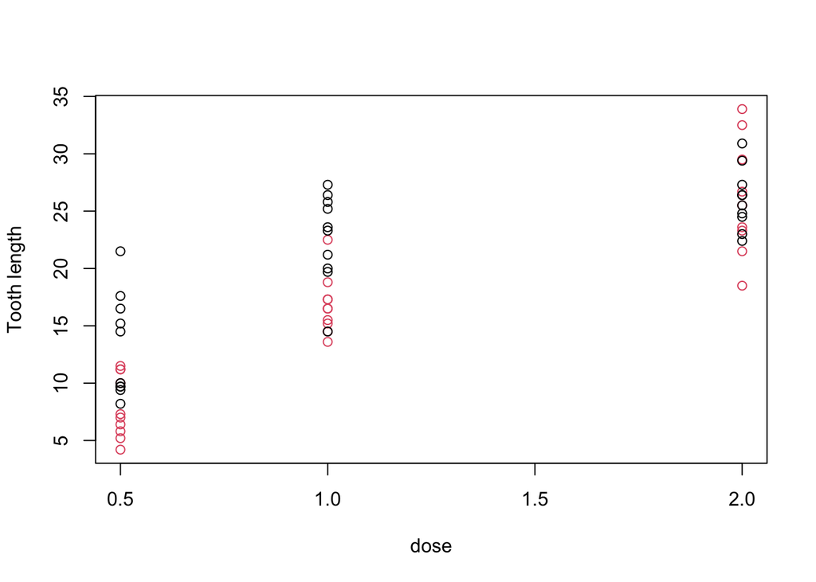

```r
plot(data$dose, data$len, col = data$supp, ylab = "Tooth length", xlab = "dose")
```